# Исследование стартапов

### Цель и задачи исследования

**Цель исследования** - Исследовать динамику и структуру финансирования стартапов, чтобы выявить закономерности венчурного рынка и оценить устойчивость возврата средств. На основе этих данных сформировать инвестиционные рекомендации по покупке и развитию перспективных компаний в условиях 2015 года.

**Задачи:**

- Проанализировать компании в зависимости от сроков финансирования;
- Классифицировать сегменты рынка на массовые, средние и нишевые;
- Исследовать распределение и аномальные значения объёмов финансирования;
- Сравнить популярность и объёмы разных типов финансирования.
- Проанализировать динамику инвестиционных раундов и объёмов финансирования по годам;
- Рассчитать долю возврата средств для разных типов финансирования;
- Сформировать рекомендации по направлениям инвестирования.

### Данные

В исследовании использованы два набора данных:

Основной датасет — cb_investments.zip. Внутри архива один файл — `cb_investments.csv`  
Дополнительный датасет — `cb_returns.csv`.

#### Описание датасета `cb_investments.csv`:

- `name` — название компании.
- `homepage_url` — ссылка на сайт компании.
- `category_list` — категории, в которых работает компания. Указываются через `|`.
- `market` — основной рынок или отрасль компании.
- `funding_total_usd` — общий объём привлечённых инвестиций в долларах США.
- `status` — текущий статус компании, например `operating`, `closed` и так далее.
- `country_code` — код страны, например USA.
- `state_code` — код штата или региона, например, CA.
- `region` — регион, например, SF Bay Area.
- `city` — город, в котором расположена компания.
- `funding_rounds` — общее число раундов финансирования.
- `participants` — число участников в раундах финансирования.
- `founded_at` — дата основания компании.
- `founded_month` — месяц основания в формате `YYYY-MM`.
- `founded_quarter` — квартал основания в формате `YYYY-QN`.
- `founded_year` — год основания.
- `first_funding_at` — дата первого финансирования.
- `mid_funding_at` — дата среднего по времени раунда финансирования.
- `last_funding_at` — дата последнего финансирования.
- `seed` — сумма инвестиций на посевной стадии.
- `venture` — сумма венчурных инвестиций.
- `equity_crowdfunding` — сумма, привлечённая через долевой краудфандинг.
- `undisclosed` — сумма финансирования нераскрытого типа.
- `convertible_note` — сумма инвестиций через конвертируемые займы.
- `debt_financing` — сумма долгового финансирования.
- `angel` — сумма инвестиций от бизнес-ангелов.
- `grant` — сумма полученных грантов.
- `private_equity` — сумма инвестиций в виде прямых (частных) вложений.
- `post_ipo_equity` — сумма финансирования после IPO.
- `post_ipo_debt` — сумма долгового финансирования после IPO.
- `secondary_market` — сумма сделок на вторичном рынке.
- `product_crowdfunding` — сумма, привлечённая через продуктовый краудфандинг.
- `round_A` — `round_H` — сумма инвестиций в соответствующем раунде.

#### Описание датасета `cb_returns.csv`:

- `year` — год возврата средств.
- `seed` — сумма возвратов от посевных инвестиций.
- `venture` — сумма возвратов от венчурных инвестиций.
- `equity_crowdfunding` — сумма, возвращённая по долевому краудфандингу.
- `undisclosed` — сумма возвратов нераскрытого типа.
- `convertible_note` — сумма возвратов через конвертируемые займы.
- `debt_financing` — сумма возвратов от долгового финансирования.
- `angel` — сумма возвратов бизнес-ангелам.
- `grant` — сумма возвратов по грантам.
- `private_equity` — сумма возвратов прямых (частных) вложений.
- `post_ipo_equity` — сумма возвратов от IPO.
- `post_ipo_debt` — сумма возвратов от долгового IPO.
- `secondary_market` — сумма возвратов от сделок на вторичном рынке.
- `product_crowdfunding` — сумма возвратов по продуктовому краудфандингу.

### Содержимое проекта

1. Загрузка и предобработка данных
2. Исследовательский анализ по срокам финансирования и сегментам рынка
3. Работа с выбросами а анализ
4. Анализ динамики
5. Итоговый вывод и рекомендации

## Загрузка и предобработка данных

### Загрузка и первичный анализ данных

```python
import pandas as pd
pd.set_option('display.max_columns', None)
pd.set_option('display.float_format', '{:,.2f}'.format)

import matplotlib.pyplot as plt
import seaborn as sns

import warnings
warnings.filterwarnings('ignore')
```

```python
investments = pd.read_csv('data/cb_investments.csv', sep=';', low_memory=False)
returns = pd.read_csv('data/cb_returns.csv')
```

Сохраним изначльное количество строк для подсчета размера оставшего датасета а выводе по разделу.

```python
original_size = investments.shape[0]
```

Функция для вывода информации о данных

```python
def view_info(df):
    print('-------------------------')
    print('Информация о таблице')
    print('-------------------------')
    df.info()
    print('-------------------------')
    print('Случайные строки датасета')
    display(df.sample(5))
    print('-------------------------')
    print('Информация о пропусках')
    display(round(df.isna().mean()*100, 1))
```

Выводим информацию по 1-ой таблице

```python
view_info(investments)
```

```
-------------------------
Информация о таблице
-------------------------
<class 'pandas.core.frame.DataFrame'>
RangeIndex: 54294 entries, 0 to 54293
Data columns (total 40 columns):
 #   Column                Non-Null Count  Dtype
---  ------                --------------  -----
 0   name                  49437 non-null  object
 1   homepage_url          45989 non-null  object
 2   category_list         45477 non-null  object
 3    market               45477 non-null  object
 4    funding_total_usd    49438 non-null  object
 5   status                48124 non-null  object
 6   country_code          44165 non-null  object
```

[output cut: 37 more lines]

|  | name | homepage_url | category_list | market | funding_total_usd | status | country_code | state_code | region | city | funding_rounds | participants | founded_at | founded_month | founded_quarter | founded_year | first_funding_at | mid_funding_at | last_funding_at | seed | venture | equity_crowdfunding | undisclosed | convertible_note | debt_financing | angel | grant | private_equity | post_ipo_equity | … |
| --- | --- | --- | --- | --- | --- | --- | --- | --- | --- | --- | --- | --- | --- | --- | --- | --- | --- | --- | --- | --- | --- | --- | --- | --- | --- | --- | --- | --- | --- | --- |
| 21238 | Kudarom | http://kudarom.com | \|Hospitality\| | Hospitality | - | operating | RUS | NaN | Moscow | Moscow | 1.00 | 1.00 | 2010-03-01 | 2010-03 | 2010-Q1 | 2,010.00 | 2010-03-01 | 2010-03-01 | 2010-03-01 | 0.00 | 0.00 | 0.00 | 0.00 | 0.00 | 0.00 | 0.00 | 0.00 | 0.00 | 0.00 | … |
| 34826 | Carreira Beauty | http://carreirabeauty.com/ | \|E-Commerce\|Small and Medium Businesses\|Market... | E-Commerce | - | operating | BRA | NaN | Sao Paulo | São Paulo | 1.00 | NaN | 2013-02-01 | 2013-02 | 2013-Q1 | 2,013.00 | 2013-07-29 | NaN | 2013-07-29 | 0.00 | 0.00 | 0.00 | 0.00 | 0.00 | 0.00 | 0.00 | 0.00 | 0.00 | 0.00 | … |
| 4193 | Skycross | http://www.skycross.com | \|Manufacturing\| | Manufacturing | 4,12,99,476 | operating | USA | FL | Florida's Space Coast | Melbourne Beach | 5.00 | 1.00 | 2000-01-01 | 2000-01 | 2000-Q1 | 2,000.00 | 2009-02-03 | 2009-02-03 | 2014-08-14 | 0.00 | 36,277,109.00 | 0.00 | 0.00 | 0.00 | 5,022,367.00 | 0.00 | 0.00 | 0.00 | 0.00 | … |
| 21884 | GeneWeave Biosciences | http://www.geneweave.com | \|Biotechnology\| | Biotechnology | 2,49,99,998 | operating | USA | CA | SF Bay Area | Los Gatos | 3.00 | 3.00 | 2010-06-11 | 2010-06 | 2010-Q2 | 2,010.00 | 2010-07-26 | 2012-02-28 | 2014-06-20 | 1,000,000.00 | 23,999,998.00 | 0.00 | 0.00 | 0.00 | 0.00 | 0.00 | 0.00 | 0.00 | 0.00 | … |
| 8648 | mDialog | http://www.mdialog.com | \|Advertising\| | Advertising | 80,27,970 | acquired | CAN | ON | Toronto | Toronto | 2.00 | 0.00 | 2005-01-01 | 2005-01 | 2005-Q1 | 2,005.00 | 2007-10-31 | 2007-10-31 | 2011-09-28 | 0.00 | 4,877,970.00 | 0.00 | 0.00 | 0.00 | 0.00 | 3,150,000.00 | 0.00 | 0.00 | 0.00 | … |

```
-------------------------
Информация о пропусках
```

```
name                    8.90
homepage_url           15.30
category_list          16.20
 market                16.20
 funding_total_usd      8.90
status                 11.40
country_code           18.70
state_code             44.40
region                 18.70
city                   20.20
funding_rounds          8.90
participants           43.90
founded_at             29.00
founded_month          29.10
founded_quarter        29.10
founded_year           29.00
first_funding_at        8.90
mid_funding_at         44.20
last_funding_at         8.90
seed                    8.90
venture                 8.90
equity_crowdfunding     8.90
undisclosed             8.90
convertible_note        8.90
debt_financing          8.90
angel                   8.90
grant                   8.90
private_equity          8.90
post_ipo_equity         8.90
post_ipo_debt           8.90
secondary_market        8.90
product_crowdfunding    8.90
round_A                 8.90
round_B                 8.90
round_C                 8.90
round_D                 8.90
round_E                 8.90
round_F                 8.90
round_G                 8.90
round_H                 8.90
dtype: float64
```

Выводим уникальные значения в столбцах с типом object

```python
### Цикл для вывода всех уникальных object. Отключил вывод для github. Занимает много места на странице
#for i in investments.select_dtypes(include=['object']).columns:
#    print('')
#    #print(i)
#    display(investments[i].unique())
```

Выводим информацию о 2-ой таблице

```python
view_info(returns)
```

```
-------------------------
Информация о таблице
-------------------------
<class 'pandas.core.frame.DataFrame'>
RangeIndex: 15 entries, 0 to 14
Data columns (total 14 columns):
 #   Column                Non-Null Count  Dtype
---  ------                --------------  -----
 0   year                  15 non-null     int64
 1   seed                  15 non-null     float64
 2   venture               15 non-null     float64
 3   equity_crowdfunding   15 non-null     float64
 4   undisclosed           15 non-null     float64
 5   convertible_note      15 non-null     float64
 6   debt_financing        15 non-null     float64
 7   angel                 15 non-null     float64
 8   grant                 15 non-null     float64
 9   private_equity        15 non-null     float64
 10  post_ipo_equity       15 non-null     float64
 11  post_ipo_debt         15 non-null     float64
 12  secondary_market      15 non-null     float64
 13  product_crowdfunding  15 non-null     float64
dtypes: float64(13), int64(1)
memory usage: 1.8 KB
-------------------------
Случайные строки датасета
```

|  | year | seed | venture | equity_crowdfunding | undisclosed | convertible_note | debt_financing | angel | grant | private_equity | post_ipo_equity | post_ipo_debt | secondary_market | product_crowdfunding |
| --- | --- | --- | --- | --- | --- | --- | --- | --- | --- | --- | --- | --- | --- | --- |
| 7 | 2007 | 70.41 | 3,585.37 | 0.01 | 55.37 | 3.22 | 125.68 | 164.51 | 0.00 | 88.81 | 24.36 | 0.00 | 0.57 | 0.00 |
| 6 | 2006 | 61.81 | 3,100.18 | 0.19 | 46.74 | 1.78 | 113.21 | 47.75 | 0.00 | 16.67 | 20.58 | 0.00 | 0.12 | 0.00 |
| 4 | 2004 | 9.93 | 555.90 | 0.00 | 33.19 | 0.01 | 13.55 | 9.18 | 0.00 | 2.19 | 3.38 | 0.00 | 0.55 | 0.00 |
| 2 | 2002 | 6.59 | 209.42 | 0.00 | 25.77 | 0.02 | 3.42 | 3.41 | 0.00 | 1.51 | 0.34 | 0.00 | 0.06 | 0.00 |
| 9 | 2009 | 160.21 | 2,501.29 | 0.18 | 37.50 | 2.25 | 394.10 | 97.21 | 0.00 | 203.70 | 76.76 | 0.00 | 0.12 | 0.02 |

```
-------------------------
Информация о пропусках
```

```
year                   0.00
seed                   0.00
venture                0.00
equity_crowdfunding    0.00
undisclosed            0.00
convertible_note       0.00
debt_financing         0.00
angel                  0.00
grant                  0.00
private_equity         0.00
post_ipo_equity        0.00
post_ipo_debt          0.00
secondary_market       0.00
product_crowdfunding   0.00
dtype: float64
```

#### Промежуточный вывод

- Все столбцы содержать пропуски. Процент пропусков варьируется от 8.9 % до 44.4 %
- Столбцы связанные с инвестициями содержат равную долю пропусков - 8.9 %.
- В столбце `market` есть неявные дубликаты. Следует проверить все таблицу на их наличие и избавиться от них
- Столбец `funding_total_usd` следует привести к числовому типу, а столбцы: `founded_at`, `founded_month`, `founded_quarter`, `founded_year`, `first_funding_at`, `mid_funding_at` и `last_funding_at` к типу дат. Сейчас эти столбцы имеют тип `object`.

В таблице `returns` 14 столбцов и 15 строк с данными о финансировании.  
На первый взгляд здесь отсутствуют аномальные значения. Пропусков в таблице нет.

### Предобработка данных

Убираем лишние пробелы в названии столбцов

```python
investments.columns = investments.columns.str.strip()
investments.columns
```

```
Index(['name', 'homepage_url', 'category_list', 'market', 'funding_total_usd',
       'status', 'country_code', 'state_code', 'region', 'city',
       'funding_rounds', 'participants', 'founded_at', 'founded_month',
       'founded_quarter', 'founded_year', 'first_funding_at', 'mid_funding_at',
       'last_funding_at', 'seed', 'venture', 'equity_crowdfunding',
       'undisclosed', 'convertible_note', 'debt_financing', 'angel', 'grant',
       'private_equity', 'post_ipo_equity', 'post_ipo_debt',
       'secondary_market', 'product_crowdfunding', 'round_A', 'round_B',
       'round_C', 'round_D', 'round_E', 'round_F', 'round_G', 'round_H'],
      dtype='object')
```

Приведем `funding_total_usd` к числовому типу

```python
investments['funding_total_usd'] = pd.to_numeric(investments['funding_total_usd'].str.replace(',', ''), errors='coerce')
print(investments['funding_total_usd'].dtype)
```

```
float64
```

Исправим тип данных в столбцах с датами.

```python
#Цикл для изменения типа данных методом pd.to_datetime
def to_date(columns):
    for col in columns:
        investments[col] = pd.to_datetime(investments[col], errors='coerce')

to_date(['founded_at', 'founded_month', 'founded_quarter', 'first_funding_at', 'mid_funding_at', 'last_funding_at'])

#Данные в этом столбце имеют числовой тип, поэтому не использую цикл.
investments['founded_year'] = pd.to_datetime(investments['founded_year'].astype(str).str.replace('.0', ''), format='%Y', errors='coerce')

investments[['founded_at', 'founded_month', 'founded_year', 'founded_quarter', 'first_funding_at', 'mid_funding_at', 'last_funding_at']].dtypes
```

```
founded_at          datetime64[ns]
founded_month       datetime64[ns]
founded_year        datetime64[ns]
founded_quarter     datetime64[ns]
first_funding_at    datetime64[ns]
mid_funding_at      datetime64[ns]
last_funding_at     datetime64[ns]
dtype: object
```

В датасете `cb_returns` сделаем столбец `year` индексом.

```python
returns = returns.set_index('year')
returns.head()
```

| year | seed | venture | equity_crowdfunding | undisclosed | convertible_note | debt_financing | angel | grant | private_equity | post_ipo_equity | post_ipo_debt | secondary_market | product_crowdfunding |
| --- | --- | --- | --- | --- | --- | --- | --- | --- | --- | --- | --- | --- | --- |
| 2000 | 16.70 | 55.40 | 0.00 | 78.21 | 0.00 | 8.66 | 6.43 | 0.00 | 0.00 | 0.94 | 0.00 | 0.20 | 0.00 |
| 2001 | 2.88 | 23.49 | 0.00 | 21.50 | 0.01 | 4.49 | 1.18 | 0.00 | 0.00 | 0.46 | 0.00 | 0.46 | 0.00 |
| 2002 | 6.59 | 209.42 | 0.00 | 25.77 | 0.02 | 3.42 | 3.41 | 0.00 | 1.51 | 0.34 | 0.00 | 0.06 | 0.00 |
| 2003 | 7.74 | 233.86 | 0.00 | 9.40 | 0.01 | 1.09 | 3.41 | 0.00 | 1.62 | 2.11 | 0.00 | 0.08 | 0.00 |
| 2004 | 9.93 | 555.90 | 0.00 | 33.19 | 0.01 | 13.55 | 9.18 | 0.00 | 2.19 | 3.38 | 0.00 | 0.55 | 0.00 |

```python
print('Количество уникальный значений до нормализации')
investments.select_dtypes(include=['object']).nunique()
```

```
Количество уникальный значений до нормализации
```

```
name             49350
homepage_url     45850
category_list    16675
market             939
status               3
country_code       115
state_code          61
region            1089
city              4188
dtype: int64
```

Обработаем текстовые данные и приведем их к единому формату.

```python
for col in investments.select_dtypes(include=['object']):
    investments[col] = investments[col].str.strip()
    investments[col] = investments[col].str.lower()

print('Количество уникальный значений после нормализации')
investments.select_dtypes(include=['object']).nunique()
```

```
Количество уникальный значений после нормализации
```

```
name             49331
homepage_url     45846
category_list    16675
market             439
status               3
country_code       115
state_code          61
region            1089
city              4188
dtype: int64
```

Избавимся от полных дубликатов

```python
print('Количество полных дубликатов')
display(investments.duplicated().sum())

investments.drop_duplicates(inplace=True)
```

```
Количество полных дубликатов
```

```
np.int64(4855)
```

Заполним пропуски `funding_total_usd`.Вместо пропусков укажем общую сумму всех инвестиций в стартап.

```python
total_invested = investments.loc[:, 'seed':'product_crowdfunding'].sum(axis=1)

investments['funding_total_usd'] = investments['funding_total_usd'].fillna(total_invested)
```

Если строки не содержат сумму финансирования или дату первого финансирования, то отбросим их.

```python
investments.drop(investments[investments['funding_total_usd'] == 0].index, inplace= True)

investments.dropna(subset=['first_funding_at'], inplace=True)
```

Заполним пропуски в значениях `mid_funding_at` на основании значений в столбцах `first_funding_at` и `last_funding_at`. В качестве нового значения вместо пропусков возьмем середину интервала между этими двумя датами.

```python
mid_date = investments['first_funding_at'] + (investments['last_funding_at'] - investments['first_funding_at']) / 2

investments['mid_funding_at'] = investments['mid_funding_at'].fillna(mid_date)
```

Пропуски оставшиеся после обработки

```python
investments.isna().sum()
```

```
name                        1
homepage_url             2314
category_list            2503
market                   2503
funding_total_usd           0
status                   1105
country_code             3819
state_code              15287
region                   3819
city                     4505
funding_rounds              0
participants            13575
founded_at               8707
founded_month            8772
founded_quarter          8772
founded_year             8707
first_funding_at            0
mid_funding_at              0
last_funding_at             0
seed                        0
venture                     0
equity_crowdfunding         0
undisclosed                 0
convertible_note            0
debt_financing              0
angel                       0
grant                       0
private_equity              0
post_ipo_equity             0
post_ipo_debt               0
secondary_market            0
product_crowdfunding        0
round_A                     0
round_B                     0
round_C                     0
round_D                     0
round_E                     0
round_F                     0
round_G                     0
round_H                     0
dtype: int64
```

```python
print('Удалено строк на этапе предобработки')
display(original_size - investments.shape[0])
print('Доля оставшихся строк от изначального количества')
display(round(investments.shape[0] / original_size, 2))
print('Итоговый размер таблицы `investments`')
display(investments.shape[0:])
```

```
Удалено строк на этапе предобработки
```

```
13389
```

```
Доля оставшихся строк от изначального количества
```

```
0.75
```

```
Итоговый размер таблицы `investments`
```

```
(40905, 40)
```

#### Промежуточный вывод

На этапе предобработки данных мы привели данные к единому формату, изменли тип данных в некоторых столбцах и избавились от дубликатов и строк с недостаточных количеством данных для дальнейшего исследования:

- Столбцы с датами имели некорректный тип данных `object` или `float`. Привели их к типу datetime
- Избавились от большого количества дубликатов в столбце `market`, число уникальных значений в нем уменьшилось примерно в 2 раза.
- Избавились от 4855 строк полных дубликатов и от 8534 строк без информации о финансировании. Всего удалено 13389 строк.
- Было отброшено 25% строк

Итоговая таблица содержит достаточнае количество строк для продолжения исследовательского анализа.

## Исследовательский анализ по срокам финансирования и сегментам рынка

### Выделяем группы по срокам финансирования

Разделим все компании на три группы:

- Единичное финансирование — был всего один раунд финансирования.
- Срок финансирования до года — между первым и последним раундом финансирования прошло не более года.
- Срок финансирования более года.

```python
investments['funding_group'] = None

days = (investments['last_funding_at'] - investments['first_funding_at']).dt.days

investments.loc[investments['funding_rounds'] == 1, 'funding_group'] = 'Единичное финансирование'
investments.loc[(investments['funding_rounds'] > 1) & (days < 365), 'funding_group'] = 'Срок финансирования до года'
investments.loc[(investments['funding_rounds'] > 1) & (days >= 365), 'funding_group'] = 'Срок финансирования более года'

investments['funding_group'].isna().sum()
```

```
np.int64(0)
```

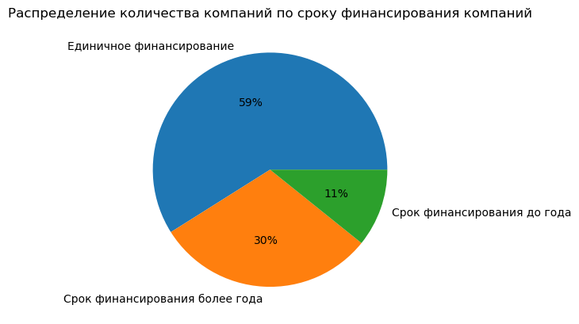

```python
investments.groupby('funding_group')['name'].count().plot(kind='pie', autopct='%1.0f%%')
plt.title('Распределение количества компаний по сроку финансирования компаний')
plt.ylabel('')
plt.show()
```

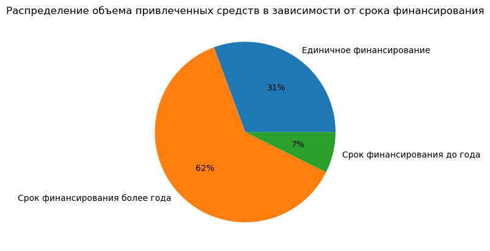

```python
investments.groupby('funding_group')['funding_total_usd'].sum().plot(kind='pie', autopct='%1.0f%%')
plt.title('Распределение объема привлеченных средств в зависимости от срока финансирования')
plt.ylabel('')
plt.show()
```

### Выделение средних и нишевых сегментов рынка

Сгруппируем отрасли и рынки по их размеру.

Для этого создадаем 3 сегмента:

- Если к рынку или отраси относится более 120 компаний, то отнесем ее к массовым - `massive`
- От 35 до 120 включительно, средние - `mid`
- До 35 компаний, нишевые - `niche`

```python
market_counts = investments['market'].value_counts()
market_category = pd.cut(market_counts, bins= [0, 34, 120, float('inf')], labels=['niche', 'mid', 'massive'])
```

Рассчитаем количество компаний в сегментах `niche` и `mid`

```python
investments['market_category'] = investments['market'].map(market_category).astype('object')
```

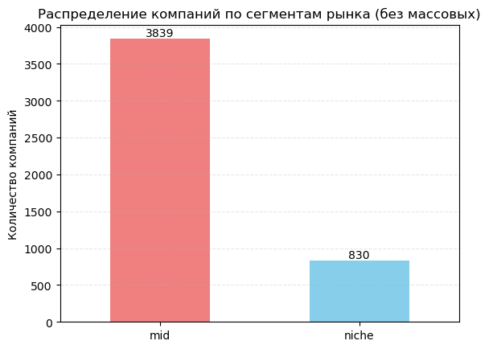

```python
filtered_market_counts = investments[investments['market_category'] != 'massive']['market_category'].value_counts()

filtered_market_counts.plot(kind='bar', color=['lightcoral', 'skyblue'], rot=0)

for i, v in enumerate(filtered_market_counts.values):
    plt.text(i, v, str(v), ha='center', va='bottom')

plt.title('Распределение компаний по сегментам рынка (без массовых)')
plt.xlabel('')
plt.ylabel('Количество компаний')
plt.grid(axis= 'y', linestyle="--", alpha=0.3)
plt.show()
```

Оставим в столбце `market` (название рынка или отрасли компании) только для массового сегмента. Для остальных заменим на значения на заглушки — `niche` для нишевых и `mid` для средних.

```python
investments.loc[investments['market_category'] == 'mid', 'market'] = 'mid'
investments.loc[investments['market_category'] == 'niche', 'market'] = 'niche'
```

#### Промежуточный вывод

Мы выделили 3 категории в зависимости от количества компаний, которые находятся в каждом сегменте `market`:

- Нишевые (`niche`) - сегменты, в которых находится до 35 компаний
- Средние (`mid`) - от 35 до 120 компаний включительно
- Массовые (`massive`) - более 120 компаний

Оставили сегменты только для массовой категории `massive`. Для остальных заменили значения на заглушки — `niche` для нишевых и `mid` для средних.

## Работа с выбросами и анализ

### Анализируем и помечаем выбросы в каждом из сегментов

Заказчика интересует обычный для рассматриваемого периода размер средств, который предоставлялся компаниям.

Оценим, какой размер общего финансирования для одной компании будет типичным, а какой — выбивающимся.

```python
investments['funding_total_usd'].describe()
```

```
count           40,905.00
mean        15,912,465.55
std        168,682,923.56
min                  1.00
25%            350,000.00
50%          2,000,000.00
75%         10,000,000.00
max     30,079,503,000.00
Name: funding_total_usd, dtype: float64
```

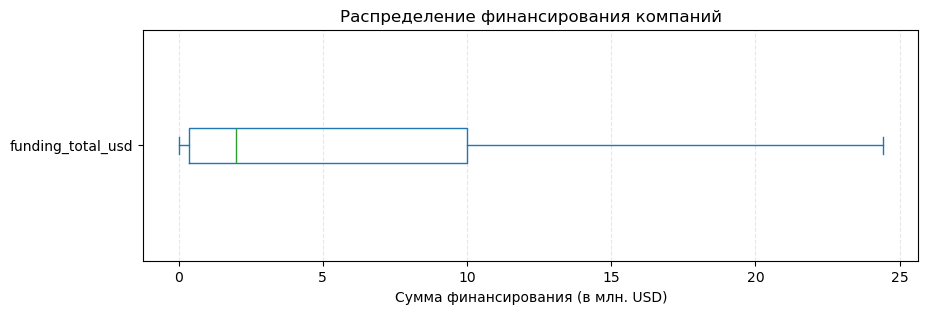

```python
(investments['funding_total_usd'] / 1000000).plot(kind='box', vert=False, showfliers=False, figsize=(10, 3))

plt.title('Распределение финансирования компаний')
plt.xlabel('Сумма финансирования (в млн. USD)')
plt.grid(axis= 'x', linestyle="--", alpha=0.3)
plt.show()
```

Определим компании с аномальным объёмом общего финансирования — используя метод IQR отдельно по каждому сегменту.

```python
investments['is_anomaly'] = False

for market_name in investments['market'].unique():

    q1 = investments[investments['market'] == market_name]['funding_total_usd'].quantile(0.25)
    q3 = investments[investments['market'] == market_name]['funding_total_usd'].quantile(0.75)
    upper_bound = q3 + 1.5 * (q3 - q1 )

    investments.loc[(investments['market'] == market_name) & (investments['funding_total_usd'] > upper_bound), 'is_anomaly'] = True
```

```python
investments.groupby('market')['is_anomaly'].mean().sort_values(ascending=False)
```

```
market
real estate            0.17
entertainment          0.17
consulting             0.17
search                 0.16
cloud computing        0.16
saas                   0.16
photography            0.16
technology             0.16
video                  0.16
niche                  0.16
travel                 0.15
networking             0.15
internet               0.15
big data               0.15
marketplaces           0.15
mid                    0.14
e-commerce             0.14
apps                   0.14
automotive             0.14
medical                0.14
sports                 0.14
social media           0.14
news                   0.13
education              0.13
fashion                0.13
mobile                 0.13
hospitality            0.13
health and wellness    0.13
messaging              0.13
clean technology       0.13
startups               0.13
social network media   0.13
finance                0.13
music                  0.12
analytics              0.12
advertising            0.12
software               0.12
public relations       0.12
curated web            0.12
security               0.12
hardware + software    0.12
design                 0.11
health care            0.11
biotechnology          0.11
enterprise software    0.11
manufacturing          0.11
games                  0.10
web hosting            0.10
nonprofits             0.10
semiconductors         0.07
Name: is_anomaly, dtype: float64
```

#### Промежуточный вывод

- В выборке из 40 905 компаний медианный объем общего финансирования составил 2 млн долларов, что можно считать типичным уровнем инвестиций для одной компании.
- Основная часть компаний получила финансирование в диапазоне от 350 тыс. до 10 млн долларов (25–75-й перцентили), поэтому этот диапазон можно считать наиболее характерным для рассматриваемого периода.
- Среднее значение финансирования (15,9 млн долларов) выше медианного (2 млн долларов), что связано с наличием компаний, которые привлекли значительно больше средств, чем большинство стартапов.
- Максимальное значение финансирования (около 30 млрд долларов) существенно превышает типичные значения
- Наибольшая доля компаний с аномально высоким финансированием наблюдается в сегментах `real estate`, `entertainment` и `consulting` — около 17% компаний.
- В технологических сегментах (`search`, `cloud computing`, `saas`, `technology`) доля аномальных значений также находится на высоком уровне — около 16%.
- Самая низкая доля компаний с аномальным финансированием отмечена в сегменте `semiconductors` — около 7%.

### Определяем границы рассматриваемого периода, отбрасываем аномалии

Проверяем наличие данных за 2014 год

```python
data_for_2014 = investments[(investments['first_funding_at'] >= '01-01-2014') &(investments['first_funding_at'] <= '31-12-2014')]
print('Объем данных за 2014 год:', data_for_2014.shape)
print('Минимум:', data_for_2014['first_funding_at'].min())
print('Максимум:', data_for_2014['first_funding_at'].max())
```

```
Объем данных за 2014 год: (6477, 43)
Минимум: 2014-01-01 00:00:00
Максимум: 2014-12-31 00:00:00
```

Исключим компании, которые получили аномальное финансирование

```python
print("Было строк:", investments.shape[0])
investments = investments.loc[~investments['is_anomaly']]
print("Осталось строк:", investments.shape[0])
```

```
Было строк: 40905
Осталось строк: 36034
```

В соответствиис техническим заданием фильтруем таблицу оставляя строки с годами, в которых было более 50 раундов.

```python
year_rounds = investments.groupby(investments['mid_funding_at'].dt.year)['funding_rounds'].sum()
investments = investments.loc[investments['mid_funding_at'].dt.year.isin(year_rounds[year_rounds >= 50].index)]
```

#### Промежуточный вывод

- По данным за 2014 год в датасете представлено 6 477 компаний, при этом период полностью покрывает весь год: с 1 января по 31 декабря 2014 года. Это позволяет считать данные за 2014 год полными в рамках предоставленного набора.
- После удаления компаний с аномально высоким финансированием количество записей уменьшилось с 40 905 до 36 034.

### Анализ типов финансирования по объёму и популярности

Привлеченные инвестиции в зависимости от типа финансирования в миллионах доларов США

```python
funding_by_type = investments.loc[:, 'seed':'product_crowdfunding'].sum().sort_values(ascending=True)
```

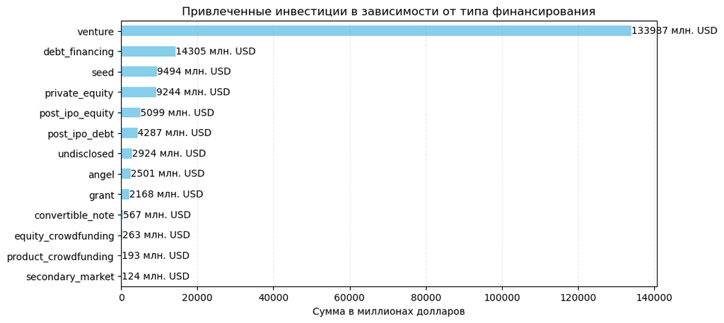

```python
(funding_by_type / 1000000).plot(kind='barh', figsize=(10, 5), color='skyblue')

for i, v in enumerate((funding_by_type / 1000000).values):
    label = f'{v:.0f} млн. USD'
    plt.text(v, i, label, ha='left', va='center', fontsize=10)

plt.title('Привлеченные инвестиции в зависимости от типа финансирования')
plt.xlabel('Сумма в миллионах долларов')
plt.grid(axis= 'x', linestyle="--", alpha=0.3)
plt.show()
```

Популярность типов финансирования

```python
count_by_type = (investments.loc[:, 'seed':'product_crowdfunding'] > 0).sum().sort_values(ascending=True)
```

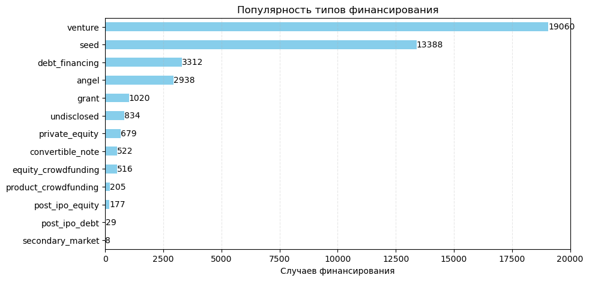

```python
count_by_type.plot(kind='barh', figsize=(10, 5), color='skyblue')

for i, v in enumerate(count_by_type.values):
    label = f"{v:.0f}"
    plt.text(v, i, label, ha='left', va='center', fontsize=10)

plt.title('Популярность типов финансирования')
plt.xlabel('Случаев финансирования')
plt.grid(axis= 'x', linestyle="--", alpha=0.3)
plt.show()
```

Средняя сумма финансирования по типам в миллионах

```python
average_by_type = (funding_by_type / count_by_type).sort_values(ascending=True)
```

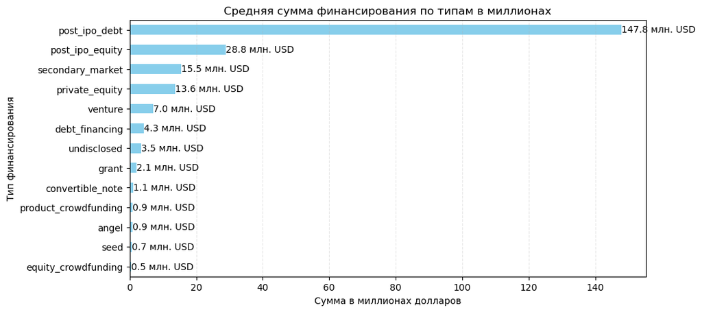

```python
(average_by_type / 1000000).plot(kind='barh', figsize=(10, 5), color='skyblue')

for i, v in enumerate((average_by_type / 1000000).values):
    label = f'{v:.1f} млн. USD'
    plt.text(v, i, label, ha='left', va='center', fontsize=10)

plt.title('Средняя сумма финансирования по типам в миллионах')
plt.xlabel('Сумма в миллионах долларов')
plt.ylabel('Тип финансирования')
plt.grid(axis= 'x', linestyle="--", alpha=0.3)
plt.show()
```

Объем возвратов в зависимости от типа финансирования

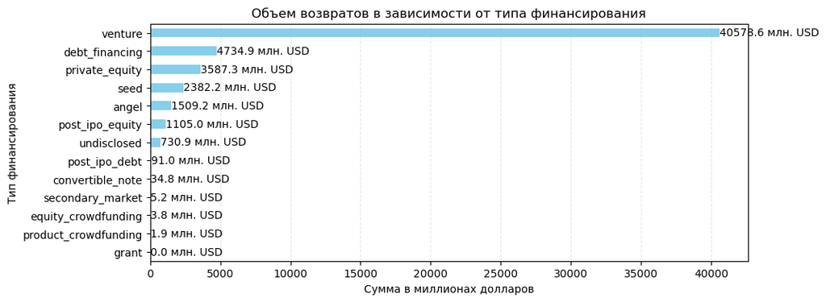

```python
returns.sum().sort_values().plot(kind='barh', figsize=(10, 4), color='skyblue')

for i, v in enumerate(returns.sum().sort_values().values):
    label = f'{v:.1f} млн. USD'
    plt.text(v, i, label, ha='left', va='center', fontsize=10)

plt.title('Объем возвратов в зависимости от типа финансирования')
plt.xlabel('Сумма в миллионах долларов')
plt.ylabel('Тип финансирования')
plt.grid(axis= 'x', linestyle="--", alpha=0.3)
plt.show()
```

#### Промежуточный вывод

- Наибольший общий объем привлеченных средств приходится на венчурный тип финансирования (`venture`) — почти 134 млрд долларов, что значительно превышает остальные виды финансирования.
- Венчурное (`venture`) финансирование встречается чаще всего (19 060 случаев), а на втором месте находятся посевные (`seed`) инвестиции (13 388 случаев). При этом `seed` имеет значительно меньший общий объем инвестиций, чем `venture`.
- Некоторые типы финансирования встречаются редко, но имеют высокий средний объем. Например, `post_ipo_debt`, `post_ipo_equity` и `private_equity` используются реже, но отличаются крупными суммами финансирования.
- Небольшие по объему и часто встречающиеся типы финансирования — `seed` и `angel`. Их суммарные объемы сильно ниже, чем у `venture`, несмотря на то, что разница в популярность не большая.
- По объему возврата средств лидирует `venture` - около 40,6 млрд долларов, далее идут `debt_financing` (4,7 млрд) и `private_equity` (3,6 млрд). Это показывает, что наиболее значимые возвраты за весь период связаны с крупными инвестиционными направлениями.

## Анализ динамики

### Динамика предоставления финансирования по годам

Динамика типичного размера средств, которые стартапы получали в рамках одного раунда финансирования

```python
investments['funding_per_round'] = investments['funding_total_usd'] / investments['funding_rounds']
avg_per_round = round(investments.groupby(investments['mid_funding_at'].dt.year)['funding_per_round'].mean() / 1000000, 1)
```

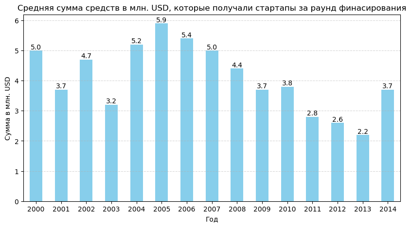

```python
avg_per_round.plot(kind='bar', figsize=(10, 5), rot= 0, color='skyblue')

for i, v in enumerate(avg_per_round.values):
    plt.text(i, v, str(v), ha='center', va='bottom')

plt.title('Средняя сумма средств в млн. USD, которые получали стартапы за раунд финасирования')
plt.xlabel('Год')
plt.ylabel('Сумма в млн. USD')
plt.grid(axis= 'y', linestyle="--", alpha=0.5)
plt.show()
```

Общее количество раундов финансирования в году

```python
count_rounds = investments.groupby(investments['mid_funding_at'].dt.year)['funding_rounds'].sum().astype(int)
```

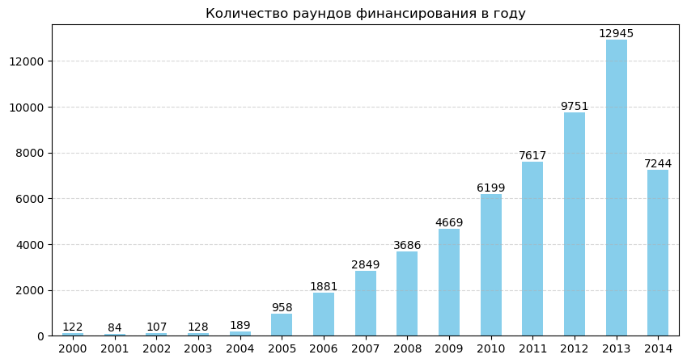

```python
count_rounds.plot(kind='bar', figsize=(10, 5), rot= 0, color='skyblue')

for i, v in enumerate(count_rounds.values):
    plt.text(i, v, str(v), ha='center', va='bottom')

plt.title('Количество раундов финансирования в году')
plt.xlabel('')
plt.grid(axis= 'y', linestyle="--", alpha=0.5)
plt.show()
```

- Максимальный средний объем финансирования в расчете на один раунд наблюдался в 2005 году и составил около 5,86 млн долларов. Высокие значения также фиксировались в 2004–2007 годах, после чего показатель постепенно снижался.
- Начиная с 2008 года типичный размер одного раунда финансирования демонстрировал нисходящую динамику и достиг минимального значения в 2013 году - около 2,21 млн долларов.
- При этом, общее количество раундов финансирования практически росло: с 122 в 2000 году до 12 945 в 2013 году.
- В 2014 году произошли изменения: количество проведенных раундов сократилось до 7 244, при этом средний объем финансирования одного раунда увеличился до 3,74 млн долларов по сравнению с предыдущим годом.
- Получается, что в 2014 году инвестиций стало проводиться меньше, но в среднем на один раунд выделялось больше средств, чем годом ранее.

### Динамика размера общего финансирования по массовым сегментам рынка для растущих в 2014 году сегментов

Размер общего финансирования `funding_total_usd` по годам и сегментам рынка.

```python
investments['funding_year'] = investments['mid_funding_at'].dt.year
funding_pivot = investments.pivot_table(index='market', columns='funding_year', values='funding_total_usd', aggfunc='sum')
```

```python
result_pivot = funding_pivot.loc[funding_pivot[2014] > funding_pivot[2013]]
result_pivot = result_pivot.drop(index=['niche', 'mid'], errors='ignore')
result_pivot
```

| funding_year market | 2000 | 2001 | 2002 | 2003 | 2004 | 2005 | 2006 | 2007 | 2008 | 2009 | 2010 | 2011 | 2012 | 2013 | 2014 |
| --- | --- | --- | --- | --- | --- | --- | --- | --- | --- | --- | --- | --- | --- | --- | --- |
| apps | NaN | NaN | NaN | NaN | NaN | NaN | 1,310,600.00 | NaN | 4,300,000.00 | 7,219,000.00 | 6,123,779.00 | 18,374,071.00 | 32,601,125.00 | 28,868,621.00 | 66,237,730.00 |
| big data | NaN | NaN | NaN | NaN | NaN | NaN | NaN | 7,780,000.00 | 2,452,515.00 | 597,375.00 | 39,233,297.00 | 60,369,158.00 | 86,413,341.00 | 78,698,922.00 | 79,232,600.00 |
| design | NaN | NaN | NaN | NaN | NaN | 9,300,000.00 | 707,000.00 | 10,800,000.00 | 5,944,302.00 | 2,150,144.00 | 17,239,975.00 | 8,899,967.00 | 39,630,692.00 | 60,958,835.00 | 68,988,516.00 |
| internet | 10,000,000.00 | NaN | 1,100,000.00 | NaN | 10,500,000.00 | 1,775,000.00 | 5,000.00 | 4,495,379.00 | 23,412,964.00 | 38,195,773.00 | 36,657,500.00 | 36,859,032.00 | 28,288,685.00 | 69,732,096.00 | 117,830,756.00 |
| manufacturing | 56,659,310.00 | 2,368,582.00 | NaN | 4,269,608.00 | 3,000,000.00 | 61,770,000.00 | 163,957,751.00 | 147,726,051.00 | 173,054,260.00 | 422,862,531.00 | 244,329,661.00 | 561,639,285.00 | 522,205,168.00 | 393,936,634.00 | 416,332,314.00 |
| medical | 24,000,000.00 | NaN | NaN | NaN | NaN | 11,090,000.00 | 20,250,000.00 | 2,100,000.00 | 28,812,744.00 | 11,566,200.00 | 25,590,338.00 | 28,540,962.00 | 44,039,600.00 | 64,469,424.00 | 175,236,064.00 |
| real estate | 2,500,000.00 | NaN | 5,275,000.00 | 6,292,200.00 | NaN | 250,000.00 | 2,080,000.00 | 33,220,000.00 | 46,613,100.00 | 38,840,213.00 | 37,344,608.00 | 20,015,128.00 | 77,320,857.00 | 92,207,655.00 | 115,567,364.00 |
| saas | NaN | NaN | 2,000,000.00 | NaN | NaN | 5,240,000.00 | 4,791,121.00 | 14,652,595.00 | 27,226,900.00 | 13,536,585.00 | 32,609,390.00 | 32,223,749.00 | 49,699,912.00 | 79,576,613.00 | 92,807,752.00 |
| startups | NaN | NaN | NaN | NaN | NaN | NaN | NaN | NaN | 5,010,387.00 | 460,700.00 | 2,111,966.00 | 19,654,403.00 | 12,358,782.00 | 18,080,552.00 | 41,501,837.00 |
| technology | NaN | 22,160,000.00 | 11,000,000.00 | NaN | 1,750,000.00 | 50,728,425.00 | 22,791,000.00 | 180,190,209.00 | 277,726,238.00 | 36,078,850.00 | 312,526,805.00 | 143,222,700.00 | 193,334,875.00 | 120,873,887.00 | 202,018,937.00 |

Оставим только те года, за которые есть данные (с 2008 года)

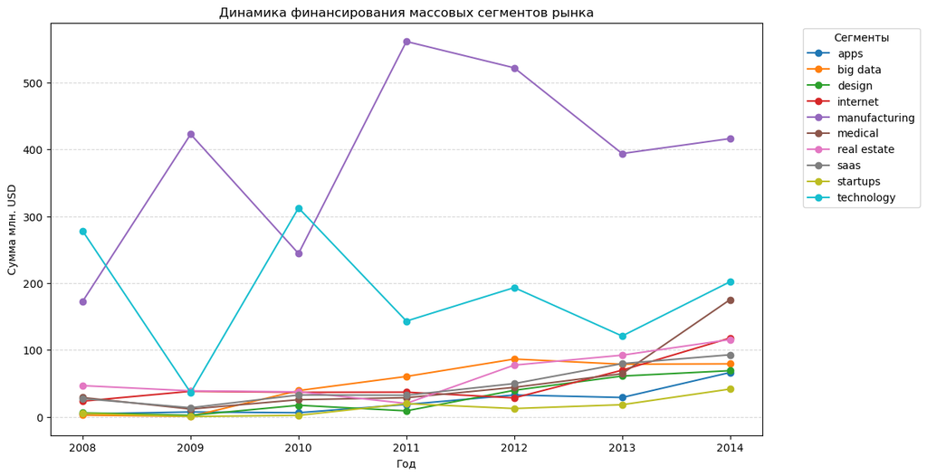

```python
(result_pivot.loc[:, result_pivot.columns >= 2008] / 1000000).T.plot(kind='line', marker='o', figsize=(12, 7))


plt.title('Динамика финансирования массовых сегментов рынка')
plt.xlabel('Год')
plt.ylabel('Сумма млн. USD')
plt.grid(axis= 'y', linestyle="--", alpha=0.5)
plt.legend(bbox_to_anchor=(1.05, 1), title='Сегменты')

plt.show()
```

- Среди массовых сегментов были отобраны только те, в которых общий объем финансирования в 2014 году оказался выше, чем в 2013 году.
- Cегменты `technology` и `medical` показали уверенный рост. В 2014 году сумма привлеченных инвестиций в них значительно увеличилась по сравнению с предыдущим годом.
- Сегменты `internet`, `apps`, `real estate` и `startups` также продемонстрировали рост финансирования в 2014 году, хотя он был менее выраженным.
- Можно сделать вывод, что в 2014 году инвесторы стали активнее вкладывать средства в технологические (`technology`) и медицинские компании (`medical`).

### Годовая динамика доли возвращённых средств по типам финансирования

Доля возвращенных средств для каждого года и вида финансирования

```python
funding_by_year = investments.groupby('funding_year')[investments.loc[:, 'seed':'product_crowdfunding'].columns].sum()
return_by_year = (returns.groupby('year')[investments.loc[:, 'seed':'product_crowdfunding'].columns].sum() * 1000000)
ratio_table = return_by_year / (funding_by_year + 1e-60)
ratio_table = ratio_table[ratio_table <= 1.0]
ratio_table
```

| year | seed | venture | equity_crowdfunding | undisclosed | convertible_note | debt_financing | angel | grant | private_equity | post_ipo_equity | post_ipo_debt | secondary_market | product_crowdfunding |
| --- | --- | --- | --- | --- | --- | --- | --- | --- | --- | --- | --- | --- | --- |
| 2000 | 1.00 | 0.15 | 0.00 | 0.36 | 0.00 | 0.62 | 0.27 | 0.00 | 0.00 | 0.27 | 0.00 | 0.03 | 0.00 |
| 2001 | 0.11 | 0.08 | 0.00 | 0.46 | 0.01 | 0.77 | NaN | 0.00 | 0.00 | NaN | 0.00 | NaN | 0.00 |
| 2002 | 0.63 | 0.61 | 0.00 | 0.61 | NaN | 0.22 | NaN | 0.00 | 0.03 | NaN | 0.00 | NaN | 0.00 |
| 2003 | 0.51 | 0.58 | 0.00 | 0.91 | NaN | NaN | 0.61 | 0.00 | NaN | NaN | 0.00 | NaN | 0.00 |
| 2004 | 0.55 | 0.77 | 0.00 | 0.34 | NaN | 0.44 | 0.83 | 0.00 | NaN | NaN | 0.00 | NaN | 0.00 |
| 2005 | 0.67 | 0.54 | 0.00 | NaN | NaN | 0.34 | 0.51 | 0.00 | 0.48 | 0.73 | 0.00 | NaN | 0.00 |
| 2006 | 0.93 | 0.34 | 0.20 | 0.65 | 0.15 | 0.80 | 0.67 | 0.00 | 0.47 | NaN | 0.00 | NaN | 0.00 |
| 2007 | 0.37 | 0.30 | NaN | 0.50 | 0.23 | 0.19 | 0.82 | 0.00 | 0.45 | NaN | 0.00 | NaN | 0.00 |
| 2008 | 0.30 | 0.19 | NaN | 0.29 | 0.06 | 0.93 | 0.41 | 0.00 | 0.68 | NaN | 0.00 | NaN | 0.00 |
| 2009 | 0.56 | 0.16 | 0.09 | 0.38 | 0.05 | 0.27 | 0.62 | 0.00 | 0.75 | NaN | 0.00 | 0.01 | 0.07 |
| 2010 | 0.53 | 0.18 | 0.05 | 0.24 | 0.07 | 0.32 | 0.64 | 0.00 | 0.26 | NaN | 0.00 | 0.20 | 0.07 |
| 2011 | 0.27 | 0.25 | 0.10 | 0.22 | 0.05 | 0.50 | 0.44 | 0.00 | 0.40 | 0.67 | 0.98 | 0.00 | 0.01 |
| 2012 | 0.19 | 0.31 | 0.03 | 0.12 | 0.05 | 0.49 | 0.50 | 0.00 | 0.88 | 0.09 | 0.01 | NaN | 0.02 |
| 2013 | 0.15 | 0.35 | 0.02 | 0.24 | 0.05 | 0.37 | 0.54 | 0.00 | 0.43 | 0.32 | 0.68 | NaN | 0.00 |
| 2014 | 0.28 | 0.69 | 0.01 | 0.16 | 0.07 | 0.20 | NaN | 0.00 | 0.16 | 0.12 | 0.06 | 0.21 | 0.01 |

График нормирования значения возврата средств для типов финансирования `venture`, `debt_financing`, `private_equity`, `seed` и `angel`.

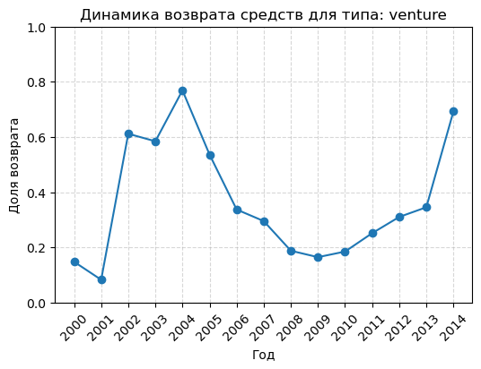

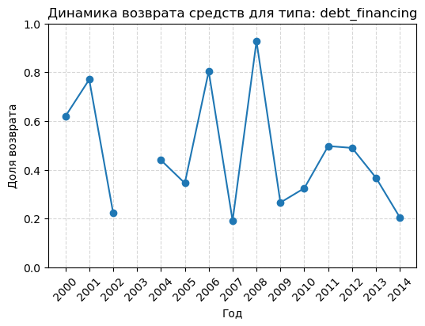

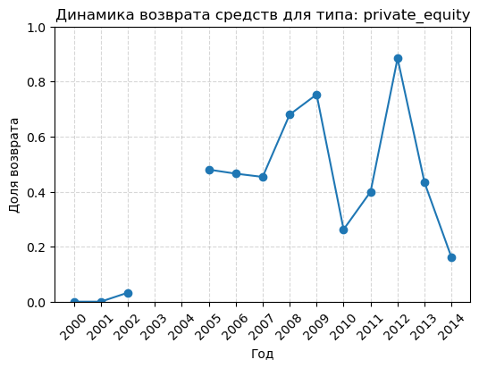

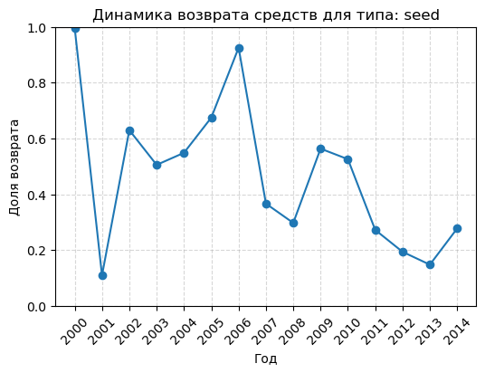

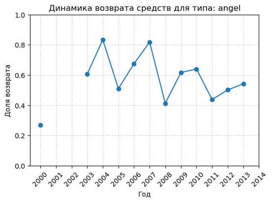

```python
for finance_type in ['venture', 'debt_financing', 'private_equity', 'seed', 'angel']:
    plt.figure(figsize=(8, 4))

    ratio_table[finance_type].plot(kind='line', marker='o', figsize=(6, 4))

    plt.xticks(ratio_table.index, rotation=45)

    plt.title(f'Динамика возврата средств для типа: {finance_type}')
    plt.xlabel('Год')
    plt.ylabel('Доля возврата')
    plt.ylim(0, 1)
    plt.grid(linestyle="--", alpha=0.5)

    plt.show()
```

- Наиболее устойчивый рост показателя возврата средств наблюдается у `venture`. После относительно низких значений в 2008–2010 годах доля возврата постепенно увеличивалась и к 2014 году достигла 0,69.
- Для `private_equity` показатель сильно менялся от года к году. Несмотря на отдельные высокие значения, устойчивый росту не наблюдается.
- `Seed` также не показывает рост. После высоких значений в начале периода доля возврата постепенно снижалась, а в 2014 году немного выросла.
- У `debt_financing` значения заметно колебались на протяжении всего периода. Показатель несколько раз резко увеличивался и снижался.
- Для `angel` доля возврата в разные годы также менялась неравномерно, а в 2014 году значение отсутствует, поэтому сделать вывод о стабильном росте невозможно.

Таким образом, среди рассмотренных типов финансирования положительную динамику демонстрирует только `venture`, тогда как остальные типы имеют значительными колебаниями показателя возврата средств.

## Итоговый вывод и рекомендации

#### Рекомендация для заказчика

На основе проведенного анализа можно рекомендовать обратить внимание на технологический и медицинский сегменты рынка. В 2014 году эти направления показали рост объемов привлеченного финансирования по сравнению с предыдущим годом. Также интерес инвесторов сохранялся к сегментам `internet` и `saas`, которые показывали рост в последние годы.

В качестве типа финансирования наиболее перспективным вариантом выглядит венчурный тип финансирования. Данный тип инвестиций является самым распространенным по количеству сделок и объему вложенных средств. Кроме того, именно для него наблюдается наиболее стабильная динамика возврата средств среди рассмотренных типов финансирования.

#### Итоговый вывод

В рамках проекта были выполнены следующие этапы:

- Проведена подготовка данных: обработаны пропуски, удалены дубликаты, проверена корректность временных и числовых значений.
- Выполнен анализ структуры финансирования стартапов: исследованы различные типы инвестиций, их объемы и популярность среди компаний.
- Рассчитаны средние объемы финансирования одного раунда и изучена динамика инвестиционной активности по годам.
- Проведен анализ массовых сегментов рынка и выявлены направления, которые показывали рост финансирования в 2014 году.
- Рассчитана доля возврата средств для разных типов финансирования и проведено сравнение их эффективности.

По результатам анализа было установлено, что венчурное инвестирование является наиболее значимым направлением: оно лидирует по объему вложенных средств, количеству сделок и возвратам инвестиций. Также было выявлено, что в 2014 году инвесторы проявляли повышенный интерес к технологическим и медицинским компаниям.

При этом некоторые выводы требуют осторожной интерпретации. Например, высокий объем финансирования не всегда означает более высокую эффективность инвестиций, так как крупные направления могут иметь большие абсолютные возвраты, но не обязательно лучший процент возврата. Кроме того, показатели отдельных типов финансирования сильно менялись по годам, поэтому для принятия окончательного инвестиционного решения потребовался бы дополнительный анализ отдельных компаний и рисков.

В целом результаты анализа согласуются между собой и показывают, что на момент 2015 года наиболее перспективным направлением выглядело инвестирование в технологические и медицинские стартапы через венчурное финансирование.